# Regresión por mínimos cuadrados: dos laboratorios reproducibles

Métodos Estadísticos Avanzados II · Sesión 2

Material docente complementario

02/11/2026

> **Propósito.** Reconstruir la lógica de la regresión por mínimos cuadrados (LS) en dos situaciones distintas: regresión lineal simple y regresión múltiple. Los datos están distribuidos en paquetes oficiales de R; **no hay que descargar archivos CSV ni crear los datos manualmente**.

**Versión docente con soluciones.** Este archivo incorpora respuestas razonadas a las preguntas y actividades, cálculos reproducibles y una explicación extensa del uso de predictores categóricos e interacciones. Los números que aparecen en las respuestas se actualizan automáticamente al pulsar **Knit** en RStudio.

## 0.1 0. Preparación

1. Abrir este archivo en RStudio.
2. Instalar una sola vez los paquetes que hagan falta. No ejecutar `install.packages()` en cada compilación.
3. Pulsar **Knit** para producir un informe HTML con texto, resultados y gráficos.

```r
obligatorios <- c("MASS", "AER", "knitr", "rmarkdown")
faltantes <- obligatorios[!vapply(obligatorios, requireNamespace,
                                  quietly = TRUE, FUN.VALUE = logical(1))]
if (length(faltantes)) {
  stop("Instale una sola vez en la consola de R: install.packages(c(",
       paste(sprintf("'%s'", faltantes), collapse = ", "), "))")
}
```

Los diagnósticos ampliados utilizan opcionalmente los paquetes `car`, `lmtest` y `sandwich`; si no están instalados, la práctica principal sigue compilando.

# 1 Parte A. Regresión lineal simple: peso de gatos

El conjunto `MASS::cats` contiene mediciones del peso corporal (`Bwt`, kg), el peso del corazón (`Hwt`, g) y el sexo (`Sex`) de gatos adultos. La pregunta es si una función lineal de `Bwt` permite explicar parte de la variación de `Hwt`. **Asociación no equivale a causalidad.**

## 1.1 1. Cargar y conocer los datos

```r
data("cats", package = "MASS")
str(cats)
```

```
## 'data.frame':    144 obs. of  3 variables:
##  $ Sex: Factor w/ 2 levels "F","M": 1 1 1 1 1 1 1 1 1 1 ...
##  $ Bwt: num  2 2 2 2.1 2.1 2.1 2.1 2.1 2.1 2.1 ...
##  $ Hwt: num  7 7.4 9.5 7.2 7.3 7.6 8.1 8.2 8.3 8.5 ...
```

```r
summary(cats)
```

```
##  Sex         Bwt            Hwt
##  F:47   Min.   :2.00   Min.   : 6.30
##  M:97   1st Qu.:2.30   1st Qu.: 8.95
##         Median :2.70   Median :10.10
##         Mean   :2.72   Mean   :10.63
##         3rd Qu.:3.02   3rd Qu.:12.12
##         Max.   :3.90   Max.   :20.50
```

```r
colSums(is.na(cats))
```

```
## Sex Bwt Hwt
##   0   0   0
```

```r
nrow(cats)
```

```
## [1] 144
```

**Antes de ajustar:** ¿qué unidades tienen las dos variables? ¿Hay datos faltantes? ¿Es razonable aproximar visualmente la relación por una recta?

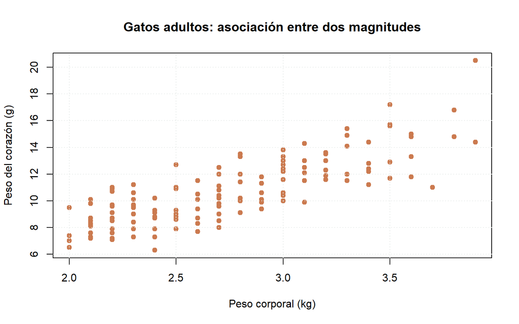

```r
plot(Hwt ~ Bwt, data = cats, pch = 19, col = "#CB7A4F",
     xlab = "Peso corporal (kg)", ylab = "Peso del corazón (g)",
     main = "Gatos adultos: asociación entre dos magnitudes")
grid(col = "#E7EBE9")
```

**Respuesta razonada · Exploración inicial.** `Bwt` se mide en **kilogramos** y `Hwt` en **gramos**. La base tiene 144 observaciones; el número total de valores faltantes es 0. El peso corporal toma valores entre 2.0 y 3.9 kg. En el diagrama aparece una tendencia **positiva aproximadamente lineal**, aunque con dispersión; por eso una recta es un primer modelo defendible, no una descripción exacta de todos los individuos. Los puntos alejados deben examinarse con residuos e influencia antes de descartarlos.

## 1.2 2. Definir el criterio LS

El modelo es

$$Hwt_i = \beta_0 + \beta_1 Bwt_i + \varepsilon_i,
\qquad
\operatorname{SSE}(\beta_0,\beta_1)
= \sum_{i=1}^{n}(Hwt_i-\beta_0-\beta_1 Bwt_i)^2.$$

El método LS minimiza la suma de cuadrados de los residuos verticales.

```r
m_simple <- lm(Hwt ~ Bwt, data = cats)
summary(m_simple)
```

```
##
## Call:
## lm(formula = Hwt ~ Bwt, data = cats)
##
## Residuals:
##    Min     1Q Median     3Q    Max
## -3.569 -0.963 -0.092  1.043  5.124
##
## Coefficients:
##             Estimate Std. Error t value Pr(>|t|)
## (Intercept)   -0.357      0.692   -0.52     0.61
## Bwt            4.034      0.250   16.12   <2e-16 ***
## ---
## Signif. codes:  0 '***' 0.001 '**' 0.01 '*' 0.05 '.' 0.1 ' ' 1
##
## Residual standard error: 1.45 on 142 degrees of freedom
## Multiple R-squared:  0.647,  Adjusted R-squared:  0.644
## F-statistic:  260 on 1 and 142 DF,  p-value: <2e-16
```

```r
coef(m_simple)
```

```
## (Intercept)         Bwt
##     -0.3567      4.0341
```

```r
confint(m_simple)
```

```
##              2.5 % 97.5 %
## (Intercept) -1.725  1.012
## Bwt          3.539  4.529
```

```r
anova(m_simple)
```

```
## Analysis of Variance Table
##
## Response: Hwt
##            Df Sum Sq Mean Sq F value Pr(>F)
## Bwt         1    548     548     260 <2e-16 ***
## Residuals 142    300       2
## ---
## Signif. codes:  0 '***' 0.001 '**' 0.01 '*' 0.05 '.' 0.1 ' ' 1
```

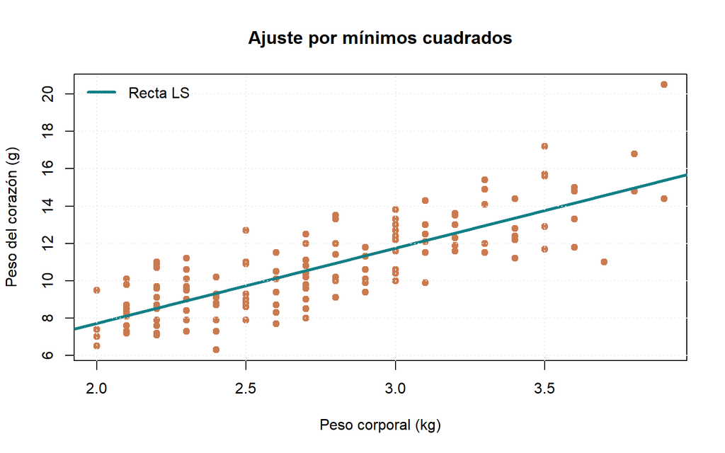

```r
plot(Hwt ~ Bwt, data = cats, pch = 19, col = "#CB7A4F",
     xlab = "Peso corporal (kg)", ylab = "Peso del corazón (g)",
     main = "Ajuste por mínimos cuadrados")
abline(m_simple, col = "#137F87", lwd = 3)
grid(col = "#E7EBE9")
legend("topleft", "Recta LS", col = "#137F87", lwd = 3, bty = "n")
```

**Para interpretar:** ¿cuántos gramos cambia en promedio el peso cardíaco estimado por cada kilogramo adicional de peso corporal? ¿Qué representa el intercepto? ¿Tiene interpretación práctica si el peso corporal es cero?

**Respuesta razonada · Ecuación estimada e interpretación.** El ajuste arroja

$$\widehat{Hwt}=
-0.357
\; + \;
4.034\,Bwt.$$

La pendiente 4.034 tiene unidades de **gramos de corazón por kilogramo corporal**: por cada kilogramo adicional, el modelo predice una diferencia de 4.034 gramos en el peso cardíaco *medio*, no en el de todos los gatos. El intercepto -0.357 g es la predicción matemática en `Bwt = 0`. No tiene una interpretación biológica razonable: cero está fuera del rango observado y no describe un gato adulto. Tampoco puede deducirse que aumentar deliberadamente el peso cause ese incremento cardíaco.

## 1.3 3. Ecuaciones normales y algoritmo `lm()`

$$\widehat{\boldsymbol\beta}=(X^{\mathsf T}X)^{-1}X^{\mathsf T}y,
\qquad X^{\mathsf T}\widehat\varepsilon=0.$$

```r
X_simple <- model.matrix(m_simple)
y_simple <- cats$Hwt
b_normales <- solve(crossprod(X_simple), crossprod(X_simple, y_simple))
comparacion <- cbind(ecuaciones_normales = as.vector(b_normales),
                     lm = unname(coef(m_simple)))
rownames(comparacion) <- colnames(X_simple)
comparacion
```

```
##             ecuaciones_normales      lm
## (Intercept)             -0.3567 -0.3567
## Bwt                      4.0341  4.0341
```

```r
crossprod(X_simple, resid(m_simple))
```

```
##                   [,1]
## (Intercept) -7.105e-15
## Bwt          3.553e-15
```

**Nota numérica:** se exhibe la fórmula de las ecuaciones normales por su valor didáctico. Para ajustes reales, `lm()` utiliza métodos basados en la factorización QR, generalmente más estables que formar la inversa.

**Actividad resuelta · Verificación matricial.** Ambas columnas de `comparacion` coinciden salvo errores de redondeo: están calculando el mismo minimizador de la suma de cuadrados. El vector $X^{\mathsf T}\widehat\varepsilon$ es numéricamente próximo a cero, lo que confirma que los residuos LS son ortogonales a las columnas de la matriz de diseño (incluida la constante). Esta propiedad es algebraica y **no** demuestra normalidad, independencia o varianza constante de los errores.

## 1.4 4. Medidas de ajuste e inferencia

```r
c(R2 = summary(m_simple)$r.squared,
  R2_ajustado = summary(m_simple)$adj.r.squared,
  error_residual = sigma(m_simple),
  SSE = sum(resid(m_simple)^2),
  grados_libertad = df.residual(m_simple))
```

```
##              R2     R2_ajustado  error_residual             SSE grados_libertad
##          0.6466          0.6441          1.4524        299.5331        142.0000
```

Identifique en `summary()` la estimación de la pendiente, su error estándar, el estadístico t y su valor p. Distinga **significación estadística** de **importancia práctica**.

**Respuesta razonada · Calidad de ajuste e inferencia.** La pendiente es 4.034, su error estándar es 0.250, el estadístico $t$ es 16.119 y el valor $p$ bilateral es <1e-12. El coeficiente de determinación es $R^2=0.647$, por lo que el ajuste explica aproximadamente 64.7 % de la variación *muestral* de `Hwt` en torno a su media. Un valor $p$ pequeño indica evidencia estadística contra $H_0:\beta_1=0$, **condicionada a los supuestos del modelo**; la relevancia práctica exige valorar el tamaño de la pendiente, sus unidades, la incertidumbre y el contexto biológico.

## 1.5 5. Diagnósticos imprescindibles

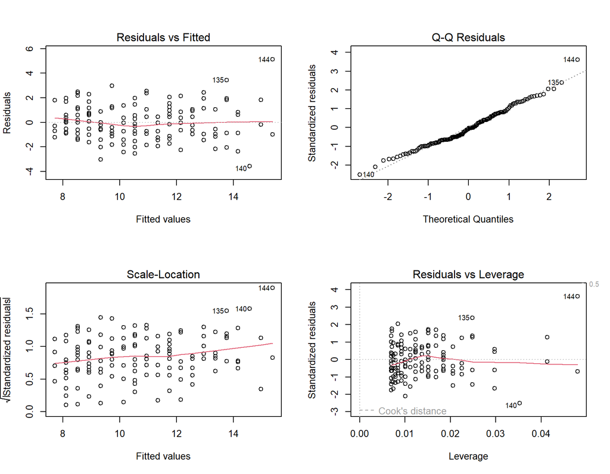

```r
par(mfrow = c(2, 2))
plot(m_simple)
```

```r
par(mfrow = c(1, 1))
```

```r
influencia_gatos <- sort(cooks.distance(m_simple), decreasing = TRUE)
head(influencia_gatos, 5)
```

```
##     144     140     135     136     142
## 0.32984 0.11437 0.07317 0.04193 0.03560
```

Discuta: linealidad, varianza aproximadamente constante, normalidad de errores para inferencia clásica y observaciones potencialmente influyentes. La independencia depende del mecanismo de muestreo, no se deduce de un gráfico.

```r
umbral_cook <- 4 / nobs(m_simple)
marcados_cook <- which(cooks.distance(m_simple) > umbral_cook)
data.frame(
  medida = c("Umbral orientativo 4/n", "Número de casos que lo superan",
             "Máxima distancia de Cook"),
  valor = c(umbral_cook, length(marcados_cook),
            max(cooks.distance(m_simple)))
)
```

```
##                           medida   valor
## 1         Umbral orientativo 4/n 0.02778
## 2 Número de casos que lo superan 5.00000
## 3       Máxima distancia de Cook 0.32984
```

**Respuesta razonada · Lectura de las cuatro gráficas.**

1. **Residuos frente a ajustados:** esperamos una nube sin curvatura sistemática; una forma curva pone en duda la especificación lineal.
2. **Escala–localización:** esperamos una dispersión relativamente uniforme; una forma de embudo sugiere heterocedasticidad.
3. **Gráfico Q–Q:** desviaciones importantes de la recta sugieren que la aproximación normal de los residuos puede ser problemática para ciertas pruebas o intervalos, especialmente en muestras pequeñas.
4. **Residuos frente a apalancamiento:** ayuda a localizar observaciones que podrían modificar apreciablemente los coeficientes.

Con el criterio **orientativo**, no automático, $D_i>4/n$, se señalan 5 casos de 144; deben comprobarse, pero no eliminarse sin motivo sustantivo. Ninguna gráfica acredita la **independencia**: esta depende de cómo fueron seleccionados y medidos los gatos. Los diagnósticos informan sobre la **plausibilidad** de supuestos, no constituyen una demostración formal de que se cumplan.

## 1.6 6. Predicción y extensión

```r
nuevo_gato <- data.frame(Bwt = 3.2)
ic_gato <- predict(m_simple, newdata = nuevo_gato,
                   interval = "confidence", level = 0.95)
ip_gato <- predict(m_simple, newdata = nuevo_gato,
                   interval = "prediction", level = 0.95)
rbind(IC_media = ic_gato[1, ], IP_individual = ip_gato[1, ])
```

```
##                 fit    lwr   upr
## IC_media      12.55 12.216 12.89
## IP_individual 12.55  9.662 15.44
```

¿Por qué el intervalo para un individuo nuevo es más ancho que el intervalo para la media condicional? Evite extrapolar fuera del intervalo observado.

**Respuesta razonada · Dos incertidumbres diferentes.** Para un peso corporal de 3.2 kg, la predicción puntual es 12.552 g. El intervalo del 95 % para **la media condicional** es [12.216, 12.888] g, mientras que el intervalo del 95 % para **un nuevo individuo** es [9.662, 15.443] g. El segundo incorpora tanto la incertidumbre al estimar la recta como la variación individual alrededor de ella; por eso es más ancho. Se trata de intervalos clásicos bajo los supuestos correspondientes, no de garantías absolutas ni de una extrapolación válida a pesos no observados.

## 1.7 6.1. Una variable explicativa categórica: el sexo del gato

Hasta aquí se ha supuesto que **todos los gatos comparten una misma recta**, independientemente de su sexo. Pero `Sex` es un *factor* con dos categorías. La regresión lineal puede incorporar categorías mediante **variables indicadoras** (*dummy variables*). No se asigna un orden cuantitativo al sexo: se usa 0/1 para expresar diferencias respecto de una categoría de referencia.

```r
class(cats$Sex)
```

```
## [1] "factor"
```

```r
levels(cats$Sex)
```

```
## [1] "F" "M"
```

```r
table(cats$Sex)
```

```
##
##  F  M
## 47 97
```

```r
contrasts(cats$Sex)
```

```
##   M
## F 0
## M 1
```

```r
head(model.matrix(~ Bwt + Sex, data = cats), 8)
```

```
##   (Intercept) Bwt SexM
## 1           1 2.0    0
## 2           1 2.0    0
## 3           1 2.0    0
## 4           1 2.1    0
## 5           1 2.1    0
## 6           1 2.1    0
## 7           1 2.1    0
## 8           1 2.1    0
```

```r
tapply(cats$Bwt, cats$Sex, range)
```

```
## $F
## [1] 2 3
##
## $M
## [1] 2.0 3.9
```

### 1.7.1 Modelo A: solo peso corporal

$$\widehat{Hwt}=\hat\beta_0+\hat\beta_1 Bwt.$$

Una sola pendiente y un solo intercepto para todos los individuos.

### 1.7.2 Modelo B: peso corporal + sexo, sin interacción

$$\widehat{Hwt}=\hat\beta_0+\hat\beta_1 Bwt
+\hat\beta_2\,\underbrace{\mathbf{1}\{Sex=M\}}_{SexM}.$$

Al separar las categorías, el modelo equivale a **dos rectas paralelas**:

$$\begin{aligned}
\text{Hembras:}\quad &\widehat{Hwt}_F=\hat\beta_0+\hat\beta_1 Bwt,\\
\text{Machos:}\quad &\widehat{Hwt}_M=(\hat\beta_0+\hat\beta_2)
+\hat\beta_1 Bwt.
\end{aligned}$$

Aquí $\hat\beta_2$ es la **diferencia estimada M − F**, en gramos, **manteniendo fijo el peso corporal**. La pendiente del peso es común a ambos sexos. No es la diferencia de los promedios brutos de `Hwt`, porque esos promedios también pueden reflejar diferencias en `Bwt` entre grupos.

### 1.7.3 Modelo C: peso corporal × sexo, con interacción

$$\widehat{Hwt}=\hat\beta_0+\hat\beta_1Bwt
+\hat\beta_2\mathbf{1}\{Sex=M\}
+\hat\beta_3Bwt\,\mathbf{1}\{Sex=M\}.$$

La interacción permite que las rectas tengan **pendientes diferentes**:

$$\begin{aligned}
\text{Hembras:}\quad &\widehat{Hwt}_F=\hat\beta_0+\hat\beta_1Bwt,\\
\text{Machos:}\quad &\widehat{Hwt}_M=(\hat\beta_0+\hat\beta_2)
+(\hat\beta_1+\hat\beta_3)Bwt.
\end{aligned}$$

La interacción `Bwt:SexM` estima la diferencia **pendiente de machos − pendiente de hembras**, en gramos por kilogramo. Cuando hay interacción, `SexM` aislado es la diferencia entre sexos **en `Bwt = 0`**: no es una comparación biológicamente relevante. A un peso válido $b$, la diferencia predicha es $\hat\beta_2+b\hat\beta_3$.

```r
m_con_sexo <- lm(Hwt ~ Bwt + Sex, data = cats)
m_interaccion <- lm(Hwt ~ Bwt * Sex, data = cats)

summary(m_con_sexo)
```

```
##
## Call:
## lm(formula = Hwt ~ Bwt + Sex, data = cats)
##
## Residuals:
##    Min     1Q Median     3Q    Max
## -3.583 -0.970 -0.095  1.043  5.102
##
## Coefficients:
##             Estimate Std. Error t value Pr(>|t|)
## (Intercept)  -0.4150     0.7273   -0.57     0.57
## Bwt           4.0758     0.2948   13.83   <2e-16 ***
## SexM         -0.0821     0.3040   -0.27     0.79
## ---
## Signif. codes:  0 '***' 0.001 '**' 0.01 '*' 0.05 '.' 0.1 ' ' 1
##
## Residual standard error: 1.46 on 141 degrees of freedom
## Multiple R-squared:  0.647,  Adjusted R-squared:  0.642
## F-statistic:  129 on 2 and 141 DF,  p-value: <2e-16
```

```r
summary(m_interaccion)
```

```
##
## Call:
## lm(formula = Hwt ~ Bwt * Sex, data = cats)
##
## Residuals:
##    Min     1Q Median     3Q    Max
## -3.773 -1.012 -0.120  0.927  4.865
##
## Coefficients:
##             Estimate Std. Error t value Pr(>|t|)
## (Intercept)    2.981      1.843    1.62  0.10796
## Bwt            2.636      0.776    3.40  0.00088 ***
## SexM          -4.165      2.062   -2.02  0.04526 *
## Bwt:SexM       1.676      0.837    2.00  0.04722 *
## ---
## Signif. codes:  0 '***' 0.001 '**' 0.01 '*' 0.05 '.' 0.1 ' ' 1
##
## Residual standard error: 1.44 on 140 degrees of freedom
## Multiple R-squared:  0.657,  Adjusted R-squared:  0.649
## F-statistic: 89.2 on 3 and 140 DF,  p-value: <2e-16
```

```r
head(model.matrix(m_interaccion), 8)
```

```
##   (Intercept) Bwt SexM Bwt:SexM
## 1           1 2.0    0        0
## 2           1 2.0    0        0
## 3           1 2.0    0        0
## 4           1 2.1    0        0
## 5           1 2.1    0        0
## 6           1 2.1    0        0
## 7           1 2.1    0        0
## 8           1 2.1    0        0
```

```r
comparacion_gatos <- anova(m_simple, m_con_sexo, m_interaccion)
comparacion_gatos
```

```
## Analysis of Variance Table
##
## Model 1: Hwt ~ Bwt
## Model 2: Hwt ~ Bwt + Sex
## Model 3: Hwt ~ Bwt * Sex
##   Res.Df RSS Df Sum of Sq    F Pr(>F)
## 1    142 300
## 2    141 299  1      0.15 0.07  0.785
## 3    140 291  1      8.33 4.01  0.047 *
## ---
## Signif. codes:  0 '***' 0.001 '**' 0.01 '*' 0.05 '.' 0.1 ' ' 1
```

```r
tabla_gatos <- data.frame(
  modelo = c("Solo Bwt", "Bwt + Sex", "Bwt * Sex"),
  R2 = vapply(list(m_simple, m_con_sexo, m_interaccion),
               function(m) summary(m)$r.squared, numeric(1)),
  R2_ajustado = vapply(list(m_simple, m_con_sexo, m_interaccion),
                        function(m) summary(m)$adj.r.squared, numeric(1)),
  AIC = AIC(m_simple, m_con_sexo, m_interaccion)$AIC
)
tabla_gatos
```

```
##      modelo     R2 R2_ajustado   AIC
## 1  Solo Bwt 0.6466      0.6441 520.1
## 2 Bwt + Sex 0.6468      0.6418 522.0
## 3 Bwt * Sex 0.6566      0.6493 520.0
```

**Actividad resuelta · Coeficientes y modelos anidados.**

- **Modelo aditivo:** la pendiente común para `Bwt` es 4.076 g/kg; el coeficiente `SexM` es -0.082 g. Por tanto, al comparar un macho y una hembra **con el mismo `Bwt`**, el valor predicho para el macho difiere en -0.082 g. Esta es una **asociación condicional**, no una diferencia causada por el sexo.
- **Modelo con interacción:** la pendiente para las hembras es 2.636 g/kg, y para los machos es 4.313 g/kg. La diferencia entre pendientes se estima en 1.676 g/kg.
- **Comparación formal:** en `anova(m_simple, m_con_sexo, m_interaccion)`, la segunda fila pregunta si **agregar `Sex`** mejora el modelo solo con peso ($p=0.785$); la tercera pregunta si **agregar la interacción** mejora el modelo aditivo ($p=0.0472$). Son contrastes F secuenciales de modelos anidados. También conviene valorar tamaño del efecto, parsimonia, diagnósticos y desempeño predictivo.

## 1.8 6.2. Dos gráficos: rectas paralelas frente a pendientes distintas

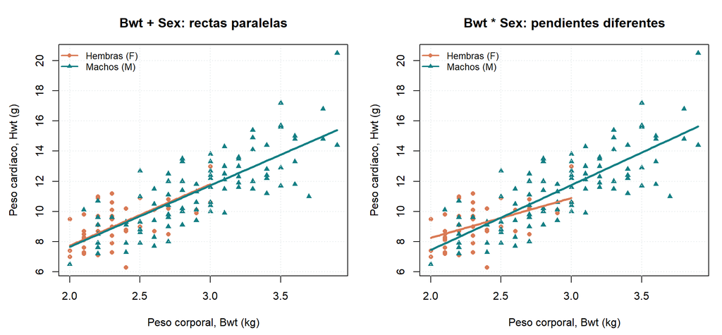

```r
colores_sexo <- c(F = "#d97a55", M = "#147f84")
simbolos_sexo <- c(F = 16, M = 17)
op <- par(mfrow = c(1, 2), mar = c(4.5, 4.5, 3.4, 1))
for (modelo in c("aditivo", "interaccion")) {
  m_actual <- if (modelo == "aditivo") m_con_sexo else m_interaccion
  plot(cats$Bwt, cats$Hwt, col = colores_sexo[as.character(cats$Sex)],
       pch = simbolos_sexo[as.character(cats$Sex)], cex = 0.9,
       xlab = "Peso corporal, Bwt (kg)", ylab = "Peso cardíaco, Hwt (g)",
       main = if (modelo == "aditivo") "Bwt + Sex: rectas paralelas"
              else "Bwt * Sex: pendientes diferentes")
  grid(col = "#e4e9ea")
  for (nivel in levels(cats$Sex)) {
    rango <- range(cats$Bwt[cats$Sex == nivel])
    xs <- seq(rango[1], rango[2], length.out = 100)
    nuevo <- data.frame(Bwt = xs,
                        Sex = factor(rep(nivel, length(xs)),
                                     levels = levels(cats$Sex)))
    lines(xs, predict(m_actual, newdata = nuevo),
          col = colores_sexo[nivel], lwd = 3)
  }
  legend("topleft", legend = c("Hembras (F)", "Machos (M)"),
         col = colores_sexo, pch = simbolos_sexo,
         lty = 1, lwd = 2, bty = "n", cex = 0.83)
}
```

```r
par(op)
```

**Respuesta razonada · Lectura visual.** Las líneas del **modelo aditivo** mantienen la misma inclinación: para cualquier valor fijo del peso, la distancia vertical entre ellas es constante e igual al coeficiente `SexM`. En el **modelo con interacción**, la separación vertical puede aumentar, disminuir o cambiar de signo según el peso; su cambio por cada kilogramo es el coeficiente `Bwt:SexM`. Los segmentos de las rectas se trazaron dentro del rango de pesos observado en cada sexo para evitar extrapolaciones visuales innecesarias.

## 1.9 6.3. Comparación justa: misma masa corporal, distinto sexo

```r
gatos_32 <- data.frame(
  Bwt = c(3.2, 3.2),
  Sex = factor(c("F", "M"), levels = levels(cats$Sex))
)
tabla_32 <- data.frame(
  sexo = gatos_32$Sex,
  Bwt_kg = gatos_32$Bwt,
  modelo_aditivo_g = as.vector(predict(m_con_sexo, newdata = gatos_32)),
  modelo_interaccion_g = as.vector(predict(m_interaccion, newdata = gatos_32))
)
tabla_32
```

```
##   sexo Bwt_kg modelo_aditivo_g modelo_interaccion_g
## 1    F    3.2            12.63                11.42
## 2    M    3.2            12.55                12.62
```

```r
# Verificación: predicción macho - predicción hembra en cada modelo.
dif_aditiva <- diff(tabla_32$modelo_aditivo_g)
dif_interaccion <- diff(tabla_32$modelo_interaccion_g)
c(diferencia_aditiva_g = dif_aditiva,
  diferencia_interaccion_g = dif_interaccion)
```

```
##     diferencia_aditiva_g diferencia_interaccion_g
##                  -0.0821                   1.1986
```

**Actividad resuelta · ¿Cómo se interpreta la categoría?** A 3.2 kg, el modelo aditivo predice 12.628 g para F y 12.545 g para M: una diferencia **M − F** de -0.082 g, igual a `SexM`. El modelo con interacción predice 11.418 g para F y 12.616 g para M: una diferencia de 1.199 g. En este segundo caso **no** debe usarse solo `SexM`; se calcula $\hat\beta_2+3.2\hat\beta_3$.

## 1.10 6.4. Centrar el peso: interpretar bien el intercepto de la interacción

```r
cats$Bwt_c <- cats$Bwt - 3.2
m_interaccion_c <- lm(Hwt ~ Bwt_c * Sex, data = cats)
coef(m_interaccion_c)
```

```
## (Intercept)       Bwt_c        SexM  Bwt_c:SexM
##      11.418       2.636       1.199       1.676
```

```r
stopifnot(isTRUE(all.equal(
  unname(coef(m_interaccion_c)[["SexM"]]),
  unname(dif_interaccion))))
stopifnot(isTRUE(all.equal(
  unname(fitted(m_interaccion_c)),
  unname(fitted(m_interaccion)))))
```

**Respuesta razonada · ¿Por qué centrar?** Como `Bwt_c = Bwt − 3.2`, el intercepto es ahora la predicción para **una hembra de 3.2 kg**, no para un animal de 0 kg. El coeficiente `SexM` del modelo centrado vale 1.199 g y representa directamente la diferencia M − F **a 3.2 kg**. El centrado cambia la **interpretación de los coeficientes**, pero deja intactas las predicciones, los residuos y el $R^2$. Por eso es especialmente útil cuando hay interacciones con variables continuas.

## 1.11 6.5. ¿Qué ocurre si se cambia la categoría de referencia?

```r
cats_refM <- cats
cats_refM$Sex <- relevel(cats_refM$Sex, ref = "M")
m_refM <- lm(Hwt ~ Bwt + Sex, data = cats_refM)
coef(m_con_sexo)
```

```
## (Intercept)         Bwt        SexM
##     -0.4150      4.0758     -0.0821
```

```r
coef(m_refM)
```

```
## (Intercept)         Bwt        SexF
##     -0.4970      4.0758      0.0821
```

```r
stopifnot(isTRUE(all.equal(unname(fitted(m_refM)),
                           unname(fitted(m_con_sexo)))))
```

**Respuesta razonada · Categorías de referencia.** Con F como referencia, `SexM` estima **M − F**. Con M como referencia, el nuevo coeficiente `SexF` estima **F − M** y por eso cambia de signo. La pendiente para `Bwt`, las predicciones, los residuos y la calidad del ajuste **no cambian**. No existe una categoría de referencia “correcta” por defecto: debe escogerse la que facilite la interpretación sustantiva y documentarse explícitamente.

**Idea transferible a muchas bases de datos.** El mismo razonamiento sirve para grupos de tratamiento, regiones, categorías de producto o niveles de escolaridad. Si hay $k$ categorías y un intercepto, R emplea por defecto $k-1$ indicadores. Un modelo aditivo representa diferencias condicionales entre grupos con pendientes compartidas; una interacción permite que el efecto del predictor numérico **dependa del grupo**. La codificación no convierte la asociación observacional en una relación causal. Conviene **evitar introducir como factor un identificador único de cada fila**: podría consumir grados de libertad sin aportar una comparación de grupos generalizable.

# 2 Parte B. Regresión múltiple: resultados escolares

`AER::CASchools` contiene información **observacional**, de 420 distritos escolares de California (1998–1999). Es útil para explicar relaciones condicionales; **no permite inferir que cambiar una variable cause por sí solo un cambio en la puntuación**.

## 2.1 7. Variables y exploración

Usaremos:

- `score`: promedio de puntuaciones en matemáticas y lectura.
- `stratio`: número de estudiantes dividido por docentes.
- `english`: porcentaje de estudiantes que aprenden inglés.
- `lunch`: porcentaje que cumple condiciones de almuerzo subsidiado.
- `income`: ingreso promedio del distrito, en miles de USD.

```r
data("CASchools", package = "AER")
escuelas <- CASchools
escuelas$score <- with(escuelas, (math + read)/2)
escuelas$stratio <- with(escuelas, students/teachers)
variables <- c("score", "stratio", "english", "lunch", "income")
escuelas <- na.omit(escuelas[variables])
dim(escuelas)
```

```
## [1] 420   5
```

```r
summary(escuelas)
```

```
##      score        stratio        english          lunch           income
##  Min.   :606   Min.   :14.0   Min.   : 0.00   Min.   :  0.0   Min.   : 5.34
##  1st Qu.:640   1st Qu.:18.6   1st Qu.: 1.94   1st Qu.: 23.3   1st Qu.:10.64
##  Median :654   Median :19.7   Median : 8.78   Median : 41.8   Median :13.73
##  Mean   :654   Mean   :19.6   Mean   :15.77   Mean   : 44.7   Mean   :15.32
##  3rd Qu.:667   3rd Qu.:20.9   3rd Qu.:22.97   3rd Qu.: 66.9   3rd Qu.:17.63
##  Max.   :707   Max.   :25.8   Max.   :85.54   Max.   :100.0   Max.   :55.33
```

```r
colSums(is.na(escuelas))
```

```
##   score stratio english   lunch  income
##       0       0       0       0       0
```

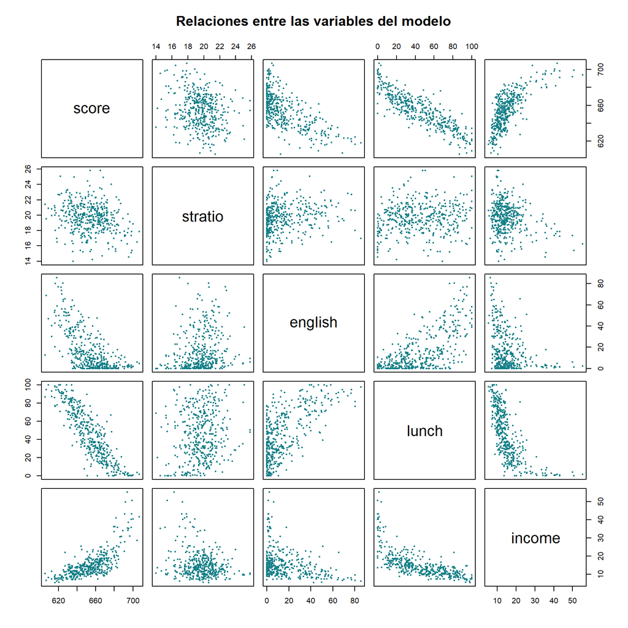

```r
pairs(escuelas, pch = 19, cex = 0.45, col = "#137F87",
      main = "Relaciones entre las variables del modelo")
```

```r
cor_score <- cor(escuelas[, variables])["score", setdiff(variables, "score")]
sort(cor_score)
```

```
##   lunch english stratio  income
## -0.8688 -0.6441 -0.2264  0.7124
```

**Actividad resuelta · Exploración.** La base original contiene 420 distritos y, después de conservar casos completos en las cinco variables elegidas, quedan 420 observaciones. La matriz de dispersión permite buscar relaciones aproximadamente lineales, agrupamientos, valores extremos y asociaciones **entre los predictores**. La mayor correlación marginal en valor absoluto de `score` es con lunch: $r=-0.869$. Este resultado solo compara relaciones **de dos variables a la vez**; no equivale a una asociación ajustada por las demás ni a un efecto causal.

## 2.2 8. De una recta a un hiperplano

$$\mathrm{score}_i=\beta_0+\beta_1\mathrm{stratio}_i
+\beta_2\mathrm{english}_i+\beta_3\mathrm{lunch}_i
+\beta_4\mathrm{income}_i+\varepsilon_i.$$

```r
m_escolar_simple <- lm(score ~ stratio, data = escuelas)
m_escolar_multiple <- lm(score ~ stratio + english + lunch + income,
                        data = escuelas)
summary(m_escolar_simple)
```

```
##
## Call:
## lm(formula = score ~ stratio, data = escuelas)
##
## Residuals:
##    Min     1Q Median     3Q    Max
## -47.73 -14.25   0.48  12.82  48.54
##
## Coefficients:
##             Estimate Std. Error t value Pr(>|t|)
## (Intercept)   698.93       9.47   73.82  < 2e-16 ***
## stratio        -2.28       0.48   -4.75  2.8e-06 ***
## ---
## Signif. codes:  0 '***' 0.001 '**' 0.01 '*' 0.05 '.' 0.1 ' ' 1
##
## Residual standard error: 18.6 on 418 degrees of freedom
## Multiple R-squared:  0.0512, Adjusted R-squared:  0.049
## F-statistic: 22.6 on 1 and 418 DF,  p-value: 2.78e-06
```

```r
summary(m_escolar_multiple)
```

```
##
## Call:
## lm(formula = score ~ stratio + english + lunch + income, data = escuelas)
##
## Residuals:
##     Min      1Q  Median      3Q     Max
## -30.709  -4.998  -0.201   4.841  28.700
##
## Coefficients:
##             Estimate Std. Error t value Pr(>|t|)
## (Intercept) 675.6082     5.3089  127.26  < 2e-16 ***
## stratio      -0.5604     0.2286   -2.45    0.015 *
## english      -0.1943     0.0314   -6.19  1.4e-09 ***
## lunch        -0.3964     0.0274  -14.46  < 2e-16 ***
## income        0.6750     0.0833    8.10  6.2e-15 ***
## ---
## Signif. codes:  0 '***' 0.001 '**' 0.01 '*' 0.05 '.' 0.1 ' ' 1
##
## Residual standard error: 8.45 on 415 degrees of freedom
## Multiple R-squared:  0.805,  Adjusted R-squared:  0.803
## F-statistic:  429 on 4 and 415 DF,  p-value: <2e-16
```

```r
confint(m_escolar_multiple)
```

```
##                2.5 %   97.5 %
## (Intercept) 665.1726 686.0438
## stratio      -1.0098  -0.1110
## english      -0.2560  -0.1326
## lunch        -0.4502  -0.3425
## income        0.5112   0.8388
```

El coeficiente de `stratio` en el modelo múltiple describe la variación promedio de `score` asociada a una unidad de `stratio`, **manteniendo constantes las demás variables del modelo**. No es una afirmación causal.

**Respuesta razonada · Interpretación completa del hiperplano.** El modelo simple estima una pendiente de `stratio` igual a -2.280 puntos de `score` por estudiante adicional por docente. En el modelo múltiple, esa pendiente es -0.560, **a igualdad de `english`, `lunch` e `income`**. La diferencia entre las dos estimaciones se debe a que la primera combina variación de `stratio` con variación de otros factores asociados; la segunda compara distritos con valores iguales de los predictores incluidos. No garantiza ausencia de confusión por variables no observadas.

La ecuación estimada del hiperplano es

$$\begin{aligned}
\widehat{score}={}&
675.608 +
(-0.560)\,stratio\\
&+(-0.194)\,english
+(-0.396)\,lunch\\
&+(0.675)\,income.
\end{aligned}$$

Las unidades de los demás coeficientes del modelo múltiple son:

- **`english`:** -0.194 puntos de `score` por **un punto porcentual** adicional de estudiantes que aprenden inglés, manteniendo constantes los demás predictores.
- **`lunch`:** -0.396 puntos de `score` por **un punto porcentual** adicional de estudiantes elegibles para almuerzo subsidiado, con las demás variables fijas.
- **`income`:** 0.675 puntos de `score` por **mil dólares adicionales** de ingreso distrital medio, con los demás predictores constantes.
- **Intercepto:** 675.608 puntos cuando todos los predictores son cero. Puede ser una referencia algebraica sin interpretación realista para un distrito.

Como el modelo es aditivo, cada pendiente describe una diferencia **condicional** bajo la restricción de que las demás pendientes no cambian con esos valores. Si hubiera razones para esperar cambios de pendientes entre grupos, habría que estudiar una interacción y justificarla.

## 2.3 9. Comparar modelos

```r
anova(m_escolar_simple, m_escolar_multiple)
```

```
## Analysis of Variance Table
##
## Model 1: score ~ stratio
## Model 2: score ~ stratio + english + lunch + income
##   Res.Df    RSS Df Sum of Sq   F Pr(>F)
## 1    418 144315
## 2    415  29616  3    114699 536 <2e-16 ***
## ---
## Signif. codes:  0 '***' 0.001 '**' 0.01 '*' 0.05 '.' 0.1 ' ' 1
```

```r
r2 <- c(simple = summary(m_escolar_simple)$r.squared,
        multiple = summary(m_escolar_multiple)$r.squared)
r2_aj <- c(simple = summary(m_escolar_simple)$adj.r.squared,
           multiple = summary(m_escolar_multiple)$adj.r.squared)
rbind(R2 = r2, R2_ajustado = r2_aj)
```

```
##              simple multiple
## R2          0.05124   0.8053
## R2_ajustado 0.04897   0.8034
```

La prueba F de modelos anidados contrasta, bajo los supuestos pertinentes, si los predictores añadidos aportan información después de incluir `stratio`. Un aumento de R² dentro de la muestra no demuestra utilidad predictiva.

**Actividad resuelta · Comparación dentro de muestra.** El $R^2$ del modelo simple es 0.051 y el del múltiple es 0.805; sus $R^2$ ajustados son, respectivamente, 0.049 y 0.803. La comparación anidada da un valor $p$ de <1e-12. La hipótesis nula conjunta es $H_0:\beta_{english}=\beta_{lunch}=\beta_{income}=0$, una vez incluido `stratio`. Mientras que $R^2$ siempre puede aumentar al añadir predictores, el $R^2$ **ajustado** penaliza la complejidad. Ninguno de los dos sustituye una evaluación fuera de muestra.

## 2.4 10. Diagnósticos del modelo múltiple

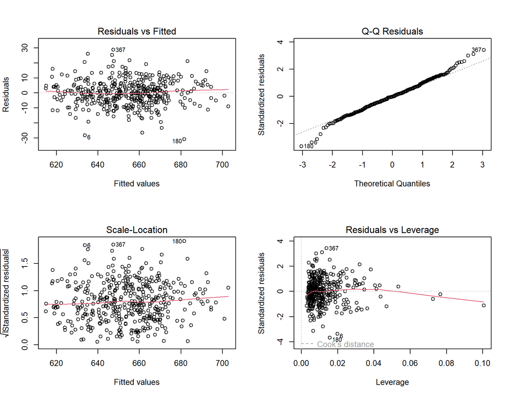

```r
par(mfrow = c(2, 2))
plot(m_escolar_multiple)
```

```r
par(mfrow = c(1, 1))
sort(cooks.distance(m_escolar_multiple), decreasing = TRUE)[1:5]
```

```
##       6     180     367     297     405
## 0.04619 0.04280 0.03308 0.03050 0.02753
```

```r
umbral_cook_esc <- 4 / nobs(m_escolar_multiple)
marcados_esc <- which(cooks.distance(m_escolar_multiple) > umbral_cook_esc)
c(umbral_Cook = umbral_cook_esc,
  casos_marcados = length(marcados_esc),
  Cook_maximo = max(cooks.distance(m_escolar_multiple)))
```

```
##    umbral_Cook casos_marcados    Cook_maximo
##       0.009524      28.000000       0.046190
```

```r
if (requireNamespace("car", quietly = TRUE)) {
  print(car::vif(m_escolar_multiple))
} else cat("Opcional: instale 'car' para calcular VIF.\n")
```

```
## stratio english   lunch  income
##   1.098   1.933   3.245   2.129
```

```r
if (requireNamespace("lmtest", quietly = TRUE)) {
  print(lmtest::bptest(m_escolar_multiple))
} else cat("Opcional: instale 'lmtest' para Breusch-Pagan.\n")
```

```
##
##  studentized Breusch-Pagan test
##
## data:  m_escolar_multiple
## BP = 3.9, df = 4, p-value = 0.4
```

```r
if (requireNamespace("lmtest", quietly = TRUE) &&
    requireNamespace("sandwich", quietly = TRUE)) {
  print(lmtest::coeftest(m_escolar_multiple,
                        vcov. = sandwich::vcovHC(m_escolar_multiple,
                                                 type = "HC3")))
} else cat("Opcional: instale 'lmtest' y 'sandwich' para errores HC3.\n")
```

```
##
## t test of coefficients:
##
##             Estimate Std. Error t value Pr(>|t|)
## (Intercept) 675.6082     6.2855  107.49  < 2e-16 ***
## stratio      -0.5604     0.2586   -2.17    0.031 *
## english      -0.1943     0.0337   -5.77  1.6e-08 ***
## lunch        -0.3964     0.0306  -12.94  < 2e-16 ***
## income        0.6750     0.0858    7.87  3.2e-14 ***
## ---
## Signif. codes:  0 '***' 0.001 '**' 0.01 '*' 0.05 '.' 0.1 ' ' 1
```

**Respuesta razonada · ¿Qué examinar en el modelo múltiple?**

- **Linealidad condicional:** residuos contra valores ajustados sin patrones curvos definidos. Una relación bivariada aparentemente curva no siempre implica no linealidad en un modelo con más predictores, ni viceversa.
- **Homocedasticidad:** residuos con amplitud similar a lo largo de los valores ajustados. Si `lmtest::bptest()` muestra evidencia de varianza no constante, los errores estándar clásicos requieren revisión; `sandwich::vcovHC(..., type = "HC3")` permite una comparación robusta de la inferencia, **sin cambiar los coeficientes LS**.
- **Normalidad e influencia:** el Q–Q se refiere a la distribución de los residuos. El criterio $4/n$ marca 28 observaciones con Cook mayor que 0.0095; identificarlas invita a estudiar sus datos, no a suprimirlas automáticamente.
- **Multicolinealidad:** predictores fuertemente relacionados pueden inflar errores estándar e inestabilizar coeficientes individuales; `car::vif()` lo cuantifica si el paquete está disponible.
- **Independencia y diseño:** distritos de una misma región podrían estar relacionados. Los gráficos no prueban independencia y la dependencia espacial o institucional merece atención en un análisis profesional.

Una práctica correcta comunica **qué indicios aparecen en las figuras**, su gravedad posible y qué conclusiones deben quedar condicionadas a ellos; no afirma automáticamente que se cumplan todos los supuestos.

## 2.5 11. Calidad predictiva fuera de muestra

```r
set.seed(2026)
indices <- sample.int(nrow(escuelas), size = floor(0.80 * nrow(escuelas)))
entrenamiento <- escuelas[indices, ]
prueba <- escuelas[-indices, ]

m_train_simple <- lm(score ~ stratio, data = entrenamiento)
m_train_multiple <- lm(score ~ stratio + english + lunch + income,
                       data = entrenamiento)

y_prueba <- prueba$score
pred_simple <- predict(m_train_simple, newdata = prueba)
pred_multiple <- predict(m_train_multiple, newdata = prueba)

indicadores <- data.frame(
  modelo = c("Referencia: promedio", "Recta simple", "Regresión múltiple"),
  RMSE = c(sqrt(mean((y_prueba - mean(entrenamiento$score))^2)),
           sqrt(mean((y_prueba - pred_simple)^2)),
           sqrt(mean((y_prueba - pred_multiple)^2))),
  MAE = c(mean(abs(y_prueba - mean(entrenamiento$score))),
          mean(abs(y_prueba - pred_simple)),
          mean(abs(y_prueba - pred_multiple)))
)
indicadores
```

```
##                 modelo   RMSE    MAE
## 1 Referencia: promedio 19.117 15.302
## 2         Recta simple 18.724 15.577
## 3   Regresión múltiple  7.931  6.336
```

La partición se hace **antes** del ajuste. Es una evaluación didáctica basada en una sola partición aleatoria; para una conclusión predictiva sólida se recomendaría validación repetida o cruzada.

**Actividad resuelta · Error fuera de muestra.** Se reservó el 20 % de los datos ($n=84$) sin usarlos para estimar parámetros; el ajuste se hizo con el 80 % ($n=336$).

El **RMSE** es $\sqrt{\frac{1}{m}\sum_{i=1}^{m}(y_i-\hat y_i)^2}$ y penaliza más los errores grandes; el **MAE** es $\frac{1}{m}\sum_{i=1}^{m}|y_i-\hat y_i|$, medido en las unidades de `score`. Para esta partición fija (`set.seed(2026)`), el RMSE mínimo corresponde a **Regresión múltiple**: 7.931 puntos. El cuadro permite comparar también el MAE y el predictor ingenuo que siempre utiliza la media de entrenamiento. Esta **clasificación de modelos podría variar** con otra partición; no debe convertirse en una sentencia general sobre cualquier población.

```r
pronostico_escuela <- predict(
  m_escolar_multiple, newdata = escuelas[1, , drop = FALSE],
  interval = "prediction", level = 0.95)
pronostico_escuela
```

```
##     fit   lwr   upr
## 1 680.1 663.4 696.8
```

**Respuesta razonada · Distrito individual.** Para las características del primer distrito de la base analítica, el valor predicho es 680.089 puntos y el intervalo de predicción clásico al 95 % abarca [663.401, 696.778] puntos. El intervalo se calculó con el modelo entrenado sobre **todas** las observaciones de `escuelas` y el distrito también pertenece a esa muestra: sirve para **ilustrar la sintaxis**, pero **no es una validación predictiva independiente**. Para medir desempeño usamos únicamente el conjunto `prueba` de la sección 11.

## 2.6 12. Reflexión integradora: preguntas **y respuestas**

Las cinco actividades siguientes recuperan el propósito de la sesión. **Primero intente resolverlas sin leer los recuadros; luego contraste su razonamiento con la solución.** Las respuestas numéricas se derivan de los modelos ajustados anteriormente.

1. En el modelo simple, reporte la ecuación, R², un intervalo para la pendiente y las conclusiones principales de los diagnósticos.
2. Compare intervalos de confianza y de predicción e interprete su diferencia.
3. En el modelo escolar, explique el cambio del coeficiente de `stratio` entre la regresión simple y la múltiple.
4. Compare R² ajustado y los errores de prueba: ¿cuál responde a la pregunta explicativa y cuál a la predictiva?
5. Justifique por qué ninguna correlación aquí demuestra una relación causal.

**Solución 1 · Recta LS, $R^2$, pendiente y diagnósticos.**

$$\widehat{Hwt}=-0.357
+ 4.034\,Bwt.$$

El $R^2$ es 0.647. El intervalo de confianza clásico al 95 % de la pendiente, obtenido por `confint(m_simple)`, es [3.539, 4.529] g/kg. **Conclusión:** se describe una asociación lineal marginal entre peso corporal y cardíaco dentro de la población representada por la muestra. La lectura de los cuatro diagnósticos debe indicar curvatura, cambios de dispersión, colas del Q–Q y puntos influyentes; la independencia queda pendiente de evaluar desde el diseño. La pendiente no tiene interpretación causal.

**Solución 2 · Intervalos.** Para `Bwt = 3.2`, ambos comparten la predicción puntual 12.552 g, pero responden a preguntas distintas: el intervalo [12.216, 12.888] g se refiere a la **media esperada** para gatos de ese peso; el intervalo [9.662, 15.443] g se refiere al peso cardíaco de **un gato individual nuevo**. El segundo incluye la variabilidad residual además de la incertidumbre de estimación y, por ello, es más amplio.

**Solución 3 · Coeficiente escolar marginal frente a condicional.** La pendiente de `stratio` pasa de -2.280 a -0.560 puntos de `score` por una unidad de ratio estudiantes/docente. El modelo simple compara distritos sin ajustar por las demás variables; el múltiple mantiene fijos los porcentajes `english`, `lunch` y el ingreso `income`. La diferencia entre coeficientes no es una anomalía de `lm()`: responde a **preguntas de asociación distintas**. El ajuste no elimina factores omitidos ni establece un efecto causal de tamaño de clase.

**Solución 4 · Explicar frente a predecir.** El $R^2$ ajustado se calcula **en el conjunto usado para estimar los modelos**, con una penalización por número de parámetros, y sirve para comparar ajuste descriptivo entre modelos anidados o razonablemente comparables. En nuestro ejemplo toma los valores 0.049 (simple) y 0.803 (múltiple). Los errores RMSE y MAE del **conjunto de prueba** responden a otra pregunta: *¿qué tan bien se pronostican casos no usados al estimar?* El menor RMSE observado aquí corresponde a Regresión múltiple, con la reserva de que proviene de una única partición 80/20.

**Solución 5 · Asociación frente a causalidad.** Las observaciones no se asignaron aleatoriamente a pesos, sexos o características distritales. Pueden existir variables omitidas (p. ej., edad, salud o raza en gatos; condiciones socioeconómicas y políticas escolares en distritos), dependencia entre observaciones y sesgos de medición o selección. Ajustar una regresión y obtener valores $p$ pequeños **no crea por sí mismo un experimento** ni prueba la dirección de una influencia. El modelo describe asociaciones y puede predecir bajo condiciones apropiadas; una afirmación causal requiere un diseño de identificación adicional.

## 2.7 13. Pregunta de ampliación: ¿qué aporta una variable categórica?

**Actividad.** Explique por qué `lm(Hwt ~ Bwt + Sex)` y `lm(Hwt ~ Bwt * Sex)` no responden exactamente a la misma pregunta. ¿Por qué es importante indicar la categoría de referencia?

**Solución.** `Hwt ~ Bwt + Sex` pregunta si, a igual peso, hay una diferencia **constante** entre F y M. `Hwt ~ Bwt * Sex` pregunta además si la asociación entre peso corporal y cardíaco **varía según el sexo**. La interacción introduce un coeficiente de diferencia de pendientes. Con F como referencia, `SexM` representa M − F; al pasar la referencia a M, `SexF` representa F − M. Cambia la forma de presentar los coeficientes, **no las predicciones**. En presencia de interacción, la diferencia entre sexos debe enunciarse **para un peso específico**, por ejemplo `Bwt = 3.2`, o mediante el modelo centrado de la sección 6.4.

## 2.8 Opción alternativa para otro contexto: ventas de sillas infantiles

`ISLR2::Carseats` tiene 400 tiendas, una respuesta `Sales` y predictores numéricos y categóricos. **Es una base simulada**; resulta útil para practicar variables indicadoras y comparar modelos, pero no para extraer conclusiones empíricas sobre el mercado real.

```r
# install.packages("ISLR2")  # ejecutar una sola vez, si es necesario
data("Carseats", package = "ISLR2")
Carseats$ShelveLoc <- relevel(Carseats$ShelveLoc, ref = "Bad")
table(Carseats$ShelveLoc)
contrasts(Carseats$ShelveLoc)
m_ventas <- lm(Sales ~ Price + Advertising + CompPrice + Income + ShelveLoc,
              data = Carseats)
summary(m_ventas)
par(mfrow = c(2,2)); plot(m_ventas); par(mfrow = c(1,1))
```

**Guía de interpretación del ejemplo opcional.** Al definir `Bad` como referencia, `ShelveLocGood` compara las ventas esperadas en tiendas con ubicación de estantería *Good* frente a *Bad*, **a igual precio, publicidad, precio de competidores e ingreso**. `ShelveLocMedium` compara *Medium* frente a *Bad* bajo las mismas condiciones. La variable tiene tres categorías, de modo que se necesitan solo **dos indicadores** con intercepto. No hay que cambiar ni duplicar la respuesta `Sales`: el diseño de regresión se ocupa de codificar el predictor categórico. Como esta práctica es **opcional** y el bloque está marcado `eval=FALSE`, sus números aparecerán solo cuando el docente lo habilite e instale `ISLR2`.

## 2.9 Referencias de procedencia de los datos

- Birkes, D. y Dodge, Y. (1993). *Alternative Methods of Regression*. Wiley, capítulo 3. **Referencia para la teoría, no fuente de `cats` ni `CASchools`.**
- Documentación oficial de R, paquete MASS: [cats](https://stat.ethz.ch/R-manual/R-devel/library/MASS/html/cats.html).
- Documentación oficial CRAN, paquete AER: [CASchools](https://search.r-project.org/CRAN/refmans/AER/html/CASchools.html).
- Documentación oficial CRAN, paquete ISLR2: [Carseats](https://search.r-project.org/CRAN/refmans/ISLR2/html/Carseats.html).
- Ayuda local: `?lm`, `?predict.lm`, `?plot.lm`, `?MASS::cats` y `?AER::CASchools`.
- Ayuda local sobre categorías e interacciones: `?factor`, `?contrasts`, `?model.matrix`, `?relevel`, `?formula`.